# R Notebook

```r
brth <- read.csv("birthdaysExample.csv", sep=",")
```

```r
summary(brth)
```

```
##      dates
##  2/6/14 :  8
##  5/22/14:  8
##  7/16/14:  8
##  1/14/14:  7
##  2/2/14 :  7
##  2/23/14:  7
##  (Other):988
```

The four calls below convert the date to a datetime format, extract days and months to a separate columns, and delete the “dates” column for convenience.

```r
brth$dates <- as.Date(brth$dates, "%m/%d")
```

```r
brth$months <- as.numeric(format(brth$dates, "%m"))
```

```r
brth$days <- as.numeric(format(brth$dates, "%d"))
```

```r
brth <- brth[c("months", "days")]
```

As the data is extracted, we may commence some introductory analysis.

```r
summary(brth)
```

```
##      months            days
##  Min.   : 1.000   Min.   : 1.0
##  1st Qu.: 3.000   1st Qu.: 8.0
##  Median : 7.000   Median :16.0
##  Mean   : 6.474   Mean   :15.7
##  3rd Qu.: 9.000   3rd Qu.:23.0
##  Max.   :12.000   Max.   :31.0
```

```r
library(ggplot2)
```

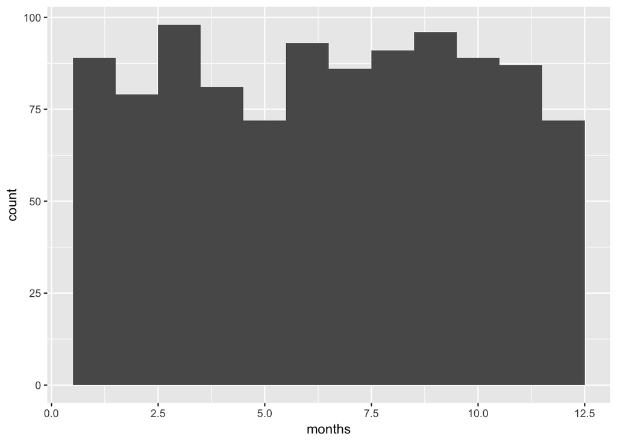

```r
ggplot(aes(x = months), data = brth) +
  geom_histogram(bins = 12)
```

Let us explore this further with frequency plots for months and for days:

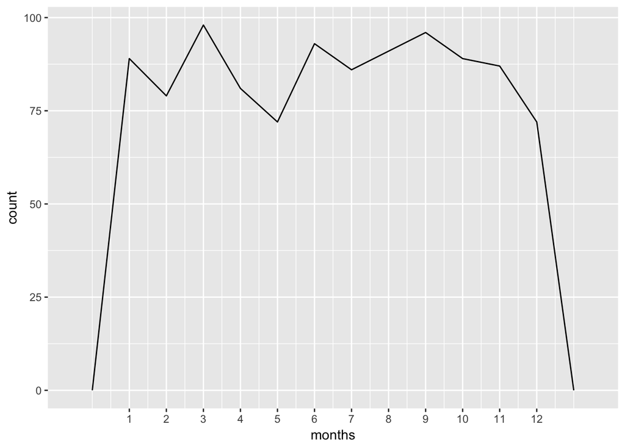

```r
ggplot(aes(x = months), data = brth) +
  geom_freqpoly(bins = 12) +
  scale_x_continuous(breaks = 1:12)
```

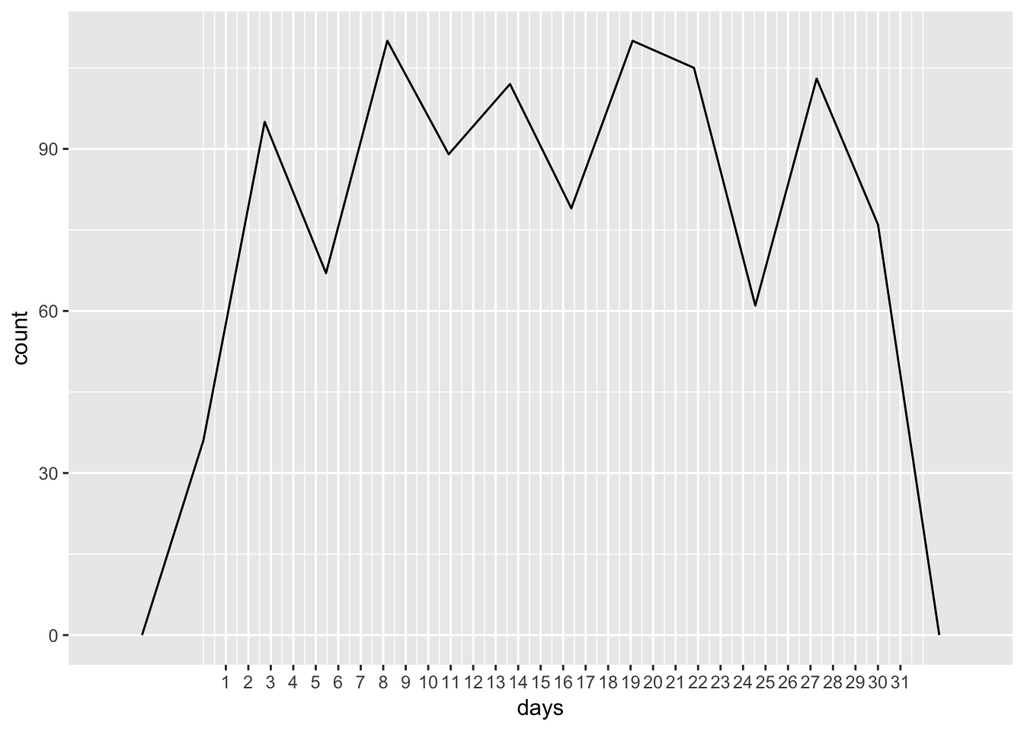

```r
ggplot(aes(x = days), data = brth) +
  geom_freqpoly(bins = 12) +
  scale_x_continuous(breaks = 1:31)
```

We will confirm the most common values for months and days by simply sorting the data:

```r
dtab <- table(brth$days)
```

```r
sort(dtab,decreasing=TRUE)[1:5]
```

```
##
## 14  9 17 19 16
## 48 40 40 40 39
```

```r
mtab <- table(brth$months)
```

```r
sort(mtab, decreasing = TRUE)[1:5]
```

```
##
##  3  9  6  8  1
## 98 96 93 91 89
```

The results of that seem to be somewhat different from results of frequency plots. The most popular day of birth turns out to be fourteents, with 48 births. The second most common value is 40 births, shared by days 9th, 17th and 19th. The most common month of birth is March, with 98 births, closely followed by September.